# act_report

## Report: act_report

*Sample view of some of the tweets*

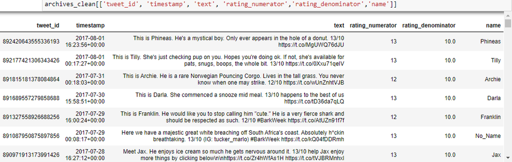

###### Insight 1:

The day with the most number of tweets is Monday

The first insight that was produced from the data was in relation to the frequency at which the WeRate Dogs twitter account sent out tweets. We found that most of the tweets were sent out on Monday and the day with the least tweets was Sunday. In order to arrive to arrive at these findings, we first identified the timestamp as the column that we were going to base our calculations on. Then, the second step was to retrieve the days of the week from the datetime object using the .dt accessor and the day_name() function.

Retrieving Day name details from the datetime object

*code snippet*

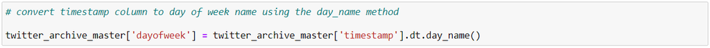

We then called the dataframe.unique method on the new column (dayofweek) to find count of each of the unique items. Since this was a categorical column, we plotted a bar chart that visualized the data. As we can see from the bar chart, there is a downward trend of the total number of tweets as the week progressed from Monday up through to Sunday. The number of tweets per day decreases steadily before levelling briefly on Thursday and Friday and the decreasing for the subsequent days. This is visualized below:

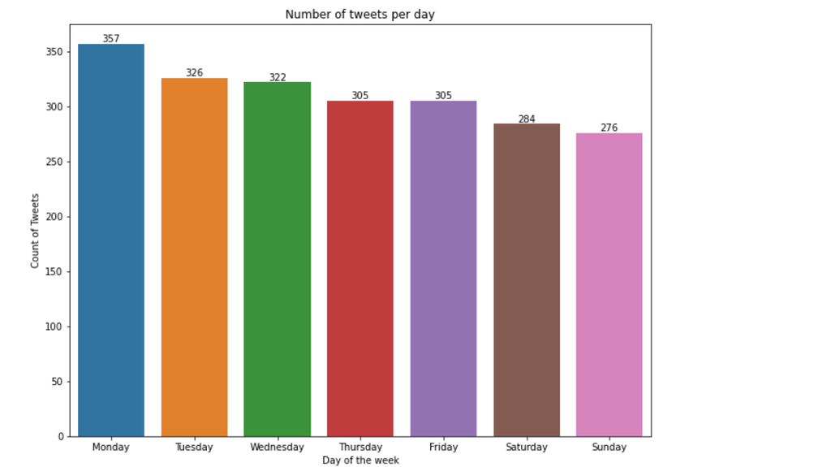

###### Insight 2.

The second insight was retrieved from the timestamp and favorite_count columns. We found that most of the favourited tweets were sent out in the afternoon than those that were sent out in the morning. To arrive at this insight, we first select favorite_count column and the group it using the timestamp column [morning/afternoon] categories.

*code snippet*

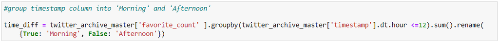

We then sum the number of favorite_counts according to each time category. The sum indicates that the sum of afternoon favorite counts stands at 5,072,153 while the morning’s count was 4,227,538.

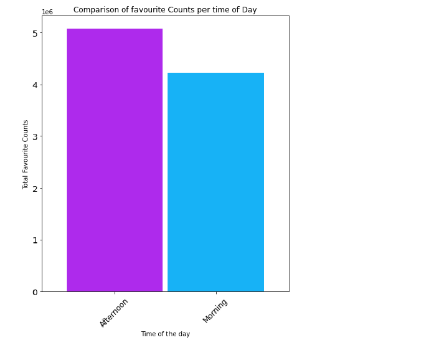

###### Insight 3:

The series object returned by the value_counts method indicates that the two items with the highest count were the unnamed dogs under the `no_name` and `incorrect_name` categories. The most common names after this category were `Charlie` and `Lucy` which had a count of 11.

The third insight was on the most common name of dogs in the dataset. In this case, this finding can be retrieved by using the value_counts method to obtain the count of unique names. The highest portion of the name column was occupied by both unnamed and misnamed entries. The most common names were Charlie and Lucy with a count of 11 followed closely by Oliver and Cooper whose count stood at 10.

Snippet of the findings

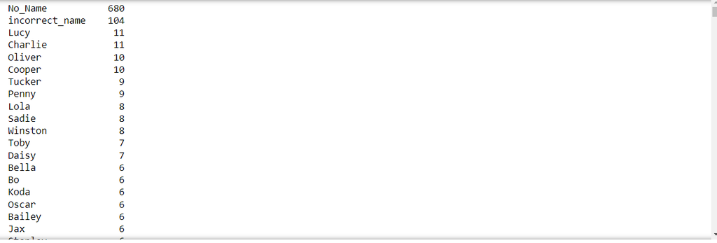